# This Means (Bayesian) War(fare)!

A Bayesian Neural Network Approach to Electronic Warfare

Margaret Morrison and Joshua DiLena (Advisor: Dr. Cohen)

November 22, 2026

## 1. Operational Motivation: The EW Battleground

- Background and Motivation
- Dataset: RadioML 2018.01A
- Research Objective
- **Electronic Warfare (EW)** has been part of military operations since World War I, evolving alongside communications technology
  - Protects aircraft and pilots in contested environments
  - Jamming can disrupt communications and operational effectiveness ([Electronic Warfare, n.d.](https://jdilena1999.github.io/IDC6940_BayesianNeuralNetworks/#ref-noauthor_under_nodate))
- **Modern military drones** increasingly depend on reliable radio-frequency (RF) links
  - Vulnerable to jamming and signal interference ([vgi_admin, 2025](https://jdilena1999.github.io/IDC6940_BayesianNeuralNetworks/#ref-vgi_admin_drones_2025))
- **Machine learning applications in wireless security**
  - Jere et al. (2024) combined supervised learning and Bayesian network inference
  - Demonstrated near-real-time jamming detection and classification ([Jere et al., 2024](https://jdilena1999.github.io/IDC6940_BayesianNeuralNetworks/#ref-10352089))
- Created by DeepSig Inc.; accessed through Kaggle ([DeepSig Inc., 2018])
- Simulated RF signals across different modulation types and noise levels ([O’Shea et al., 2018])
- **Full dataset characteristics:**
  - 2,555,904 signal frames
  - 24 modulation types
  - 26 SNR levels (-20 dB to +30 dB)
  - 1,024 in-phase and quadrature (I/Q) samples per signal
- **Research sample:**
  - Random subsample of N = 5,000 signal frames
- Provides a framework for examining how signal quality changes under varying noise conditions ([O’Shea et al., 2018])
- Model **Signal-to-Noise Ratio (SNR)** as the response variable using neural networks and Bayesian analysis
- Bayesian methods:
  - Treat model parameters as probability distributions rather than fixed values
  - Incorporate prior knowledge
  - Allow results to be expressed as probability statements ([Berger, 2000])
- **Bayesian Neural Networks (BNNs):**
  - Provide a framework for addressing overfitting ([Bishop, 1997](https://jdilena1999.github.io/IDC6940_BayesianNeuralNetworks/#ref-Bishop1997))
  - Quantify predictive uncertainty, particularly useful with noisy data ([Mullachery et al., 2018])
  - Require consideration of scalability with large datasets ([Jospin et al., 2022](https://jdilena1999.github.io/IDC6940_BayesianNeuralNetworks/#ref-9756596))
  - Bayesian priors provide a form of regularization comparable to weight decay ([Bishop, 1997])

## What the Data Revealed

### SNR and modulation

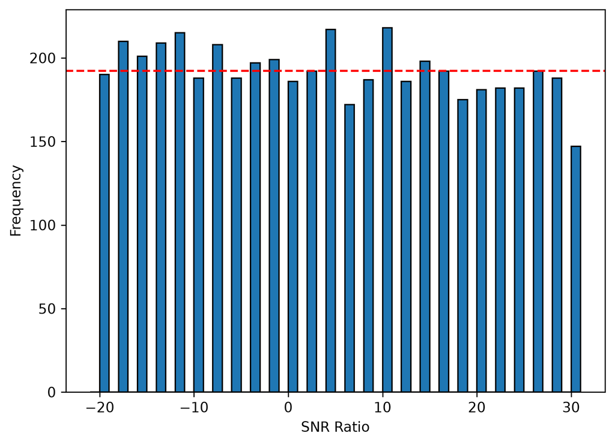

SNR distribution across the sampled signal frames.

### Feature relationships

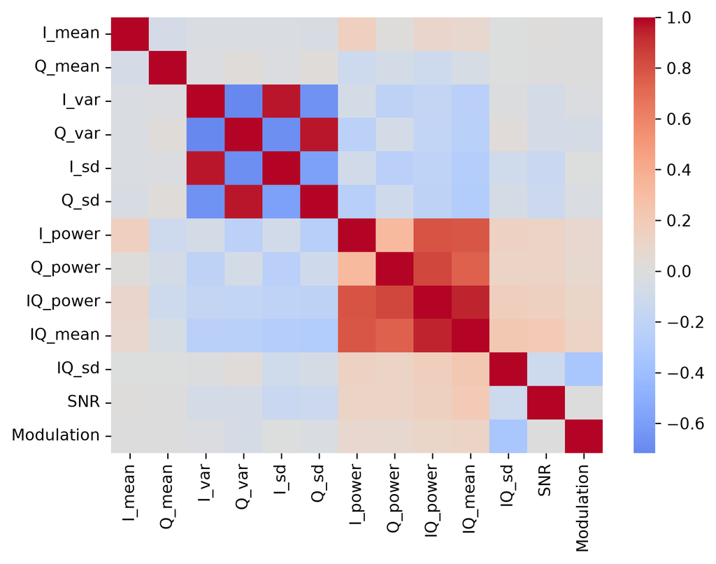

Relationships among the signal-derived predictors.

## Signal Characteristics

### Signal means

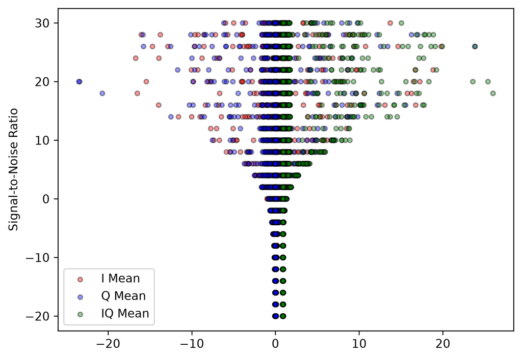

### Signal power

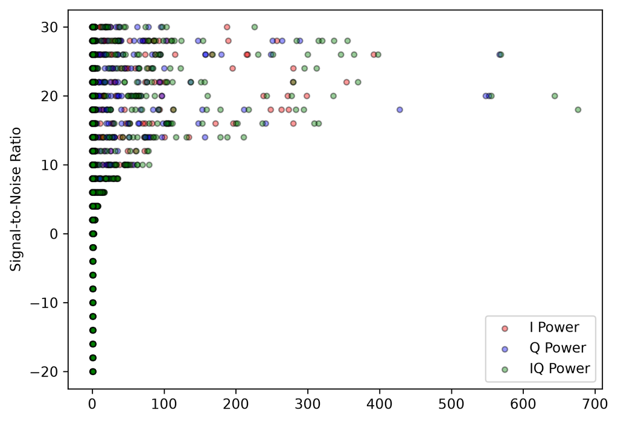

## Bayesian Neural Network and Probability Model

### Network Architecture

- Five hidden layers with ReLU activation
- TensorFlow Probability `DenseFlipout` layers
- Normal(0, 1) weight priors
- Gaussian output with predicted mean (μ) and standard deviation (σ)

### Probability Model

- Models SNR as a predictive distribution
- Gaussian likelihood for observed SNR
- Negative log-likelihood (NLL) loss
- Adam optimizer

**Tip**

**Key distinction:** Rather than returning only one SNR estimate, the network estimates a distribution representing the prediction and its spread.

## Training, Validation, and Evaluation

**Data partition**

- 70% training
- 30% held-out testing
- 20% of training data used for validation

**Model training**

- 200 epochs
- Adam optimizer
- Validation monitored during training

**Evaluation**

- Mean squared error (MSE)
- Mean absolute error (MAE)
- Negative Log-Loss

## How Well Did the Model Predict SNR?

### Training loss

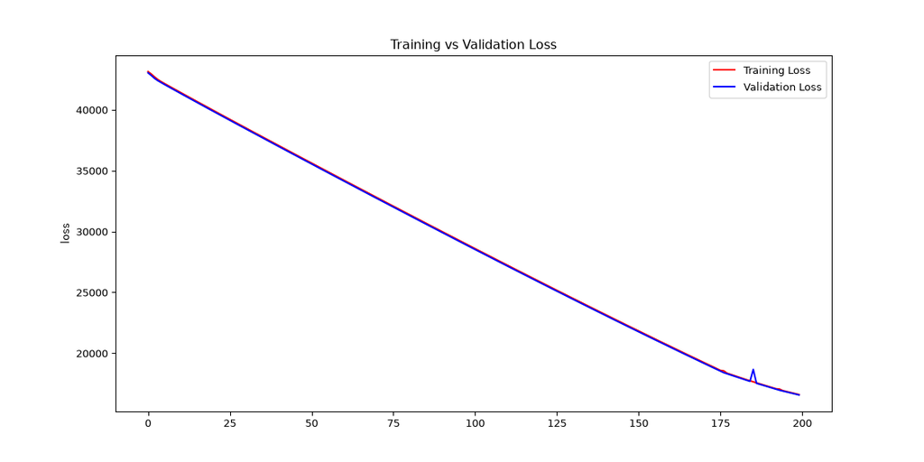

### MAE

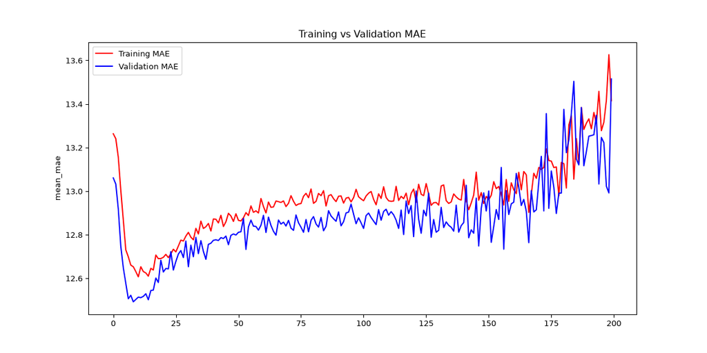

### MSE

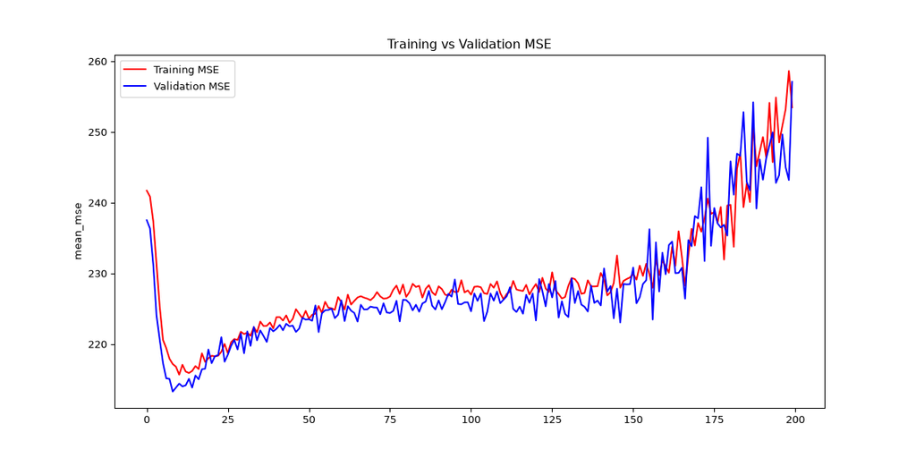

**Training and Validation performance**

- During model training, our model was successful in minimizing our loss function (Negative Log-Loss)

# What Does Predictive Uncertainty Tell Us?

**A Bayesian model provides more than a single SNR estimate.**

- **Aleatoric uncertainty:** variation associated with the observations and signal conditions.
- **Epistemic uncertainty:** uncertainty associated with what the model has learned.
- **Predictive uncertainty:** combines both sources.

$$\sigma_{\text{total}}(x) = \sqrt{\sigma_{\text{epi}}^2(x) + \sigma_{\text{ale}}^2(x)}$$
where
$$\sigma_{\text{epi}}^2(x) = \frac{1}{T}\sum_{t=1}^{T}\left(\mu_t(x) - \bar{\mu}(x)\right)^2,
\qquad
\sigma_{\text{ale}}^2(x) = \frac{1}{T}\sum_{t=1}^{T}\sigma_t^2(x)$$

## Conclusion

- The Takeaway
- Limitations and Next Steps
- Future work

**The value of the Bayesian approach is the ability to examine prediction accuracy and uncertainty together.**

- SNR prediction provides an estimate of signal quality.
- Predictive uncertainty adds information about how variable or uncertain that estimate may be.
- This is a potential foundation for further investigation—not a demonstrated real-time electronic-warfare capability.
- Random sample of 5,000 simulated frames.
- No real-world RF deployment.
- Results depend on the selected features and model configuration.
- Evaluate the full RadioML benchmark.
- Test on additional or out-of-distribution signal conditions.
- Investigate implementation on software-defined radio hardware.

# Final Takeaway

- A useful SNR prediction is not only about the estimated value—it is also about understanding the uncertainty surrounding it.
- Our capstone project demonstrates how a Bayesian neural network can be used to predict signal-to-noise ratio from signal-derived features while providing a measure of predictive uncertainty.
- The results highlight the value of considering not only what a model predicts, but also how confident it is in those predictions.

## References

Bai, Runbo, Xiumei Qiu, and Maosen Cao. 2009. “Factor Sensitivity Analysis for Multivariable Systems Using Bayesian Neural Networks.” *2009 International Conference on Computational Intelligence and Security* 1: 30–33. https://doi.org/10.1109/CIS.2009.43.

Berger, James O. 2000. “Bayesian Analysis: A Look at Today and Thoughts of Tomorrow.” *Journal of the American Statistical Association* 95 (452): 1269–76. https://doi.org/10.1080/01621459.2000.10474328.

Bishop, Christopher M. 1997. “Bayesian Neural Networks.” *Journal of the Brazilian Computer Society* 4 (1). https://doi.org/10.1590/s0104-65001997000200006.

Deepsig Inc., pinxau1000. 2018. *RadioML 2018.01A*. Kaggle. https://www.kaggle.com/datasets/pinxau1000/radioml2018.

*Electronic Warfare*. n.d. Accessed September 28, 2026. https://apps.dtic.mil/landingpage/maint.html.

Goligher, Ewan C., and Michael O. Harhay. 2024. “What Is the Point of Bayesian Analysis?” *American Journal of Respiratory and Critical Care Medicine* 209 (5): 485–87. https://doi.org/10.1164/rccm.202310-1757vp.

Hernandez-Lobato, Jose Miguel, and Ryan Adams. 2015. “Probabilistic Backpropagation for Scalable Learning of Bayesian Neural Networks.” In *Proceedings of the 32nd International Conference on Machine Learning*, edited by Francis Bach and David Blei, vol. 37. Proceedings of Machine Learning Research. PMLR. https://proceedings.mlr.press/v37/hernandez-lobatoc15.html.

Jere, Shashank, Ying Wang, Ishan Aryendu, Shehadi Dayekh, and Lingjia Liu. 2024. “Bayesian Inference-Assisted Machine Learning for Near Real-Time Jamming Detection and Classification in 5G New Radio (NR).” *IEEE Transactions on Wireless Communications* 23 (7): 7043–59. https://doi.org/10.1109/TWC.2023.3337058.

Jospin, Laurent Valentin, Hamid Laga, Farid Boussaid, Wray Buntine, and Mohammed Bennamoun. 2022. “Hands-on Bayesian Neural Networks—a Tutorial for Deep Learning Users.” *IEEE Computational Intelligence Magazine* 17 (2): 29–48. https://doi.org/10.1109/MCI.2022.3155327.

Lampinen, Jouko, and Aki Vehtari. 2001. “Bayesian Approach for Neural Networks—Review and Case Studies.” *Neural Networks* 14 (3): 257–74. https://doi.org/10.1016/s0893-6080(00)00098-8.

Mullachery, Vikram, Aniruddh Khera, and Amir Husain. 2018. “Bayesian Neural Networks.” *CoRR* abs/1801.07710. http://arxiv.org/abs/1801.07710.

O’Shea, Timothy James, Tamoghna Roy, and T. Charles Clancy. 2018. “Over-the-Air Deep Learning Based Radio Signal Classification.” *IEEE Journal of Selected Topics in Signal Processing* 12 (1): 168–79. https://doi.org/10.1109/jstsp.2018.2797022.

O’Shea, Timothy, and Jakob Hoydis. 2017. “An Introduction to Deep Learning for the Physical Layer.” *IEEE Transactions on Cognitive Communications and Networking* 3 (4): 563–75. https://doi.org/10.1109/TCCN.2017.2758370.

Snoek, Jasper, Oren Rippel, Kevin Swersky, et al. 2015. “Scalable Bayesian Optimization Using Deep Neural Networks.” *International Conference on Machine Learning*, 2171–80.

Victoria, A. Helen, and G. Maragatham. 2020. “Automatic Tuning of Hyperparameters Using Bayesian Optimization.” *Evolving Systems* 12 (1): 217–23. https://doi.org/10.1007/s12530-020-09345-2.